# 10Alytics_Hackathon_Dec_2022-Copy1 slides

## Tackling the Health Crises in Africa

## by Gift Omodu

### Data Overview

The data consist of records from 1990 to 2019. These records includes: Causes of death, Number of death by age groups, Medical doctors per 10,000 population, Country codes, World population, Health expenditure(% of GDP)

## INSIGHTS

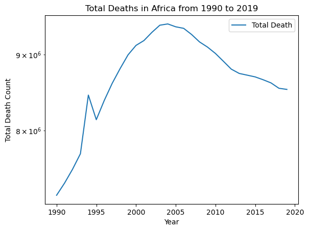

```python
a_yr_new.plot(kind='line', y='Total Death')
plt.title('Total Deaths in Africa from 1990 to 2019')
plt.ylabel('Total Death Count')
plt.yscale('log');
```

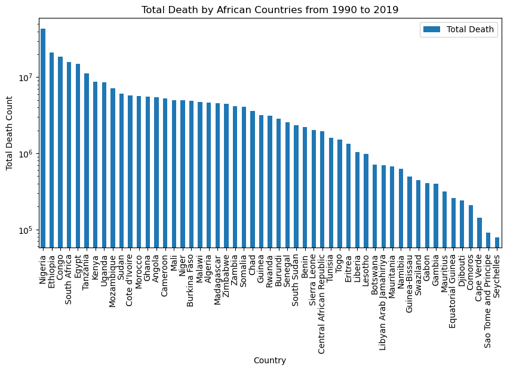

```python
ax.plot(kind='bar', y='Total Death', figsize=[10, 5])
plt.title('Total Death by African Countries from 1990 to 2019')
plt.xlabel('Country')
plt.ylabel('Total Death Count')
plt.yscale('log');
```

The fisrt five bars represents the top five highest death count by country. The data reveals that Seychelles had the lowest death rate and Nigeria accounting for the highest.

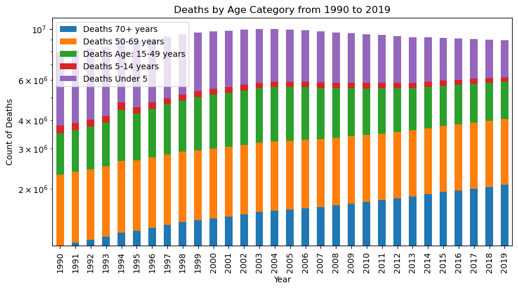

```python
afr_age_df.plot(kind='bar', stacked=True, figsize=[10,5])
plt.title('Deaths by Age Category from 1990 to 2019')
plt.ylabel('Count of Deaths')
plt.yscale('log');
```

In all five age groups, we can see a pattern in death population across 1990 to 2019. The Death population of 50 years and above increased gradually over the years. That of group 13-49 years witnessed a gentle rise and fall in death population. The 5-14 years groups are atributed with a gentle rise from 1990 with a spike on 1994, then declining the next year with an associated gentle rise up until 2004 where in remained relatively fixed till 2013 and increased further from there. The under 5 years groups had a gentle rise from 1990, reaching a peak at 2004 and then falling gradually.

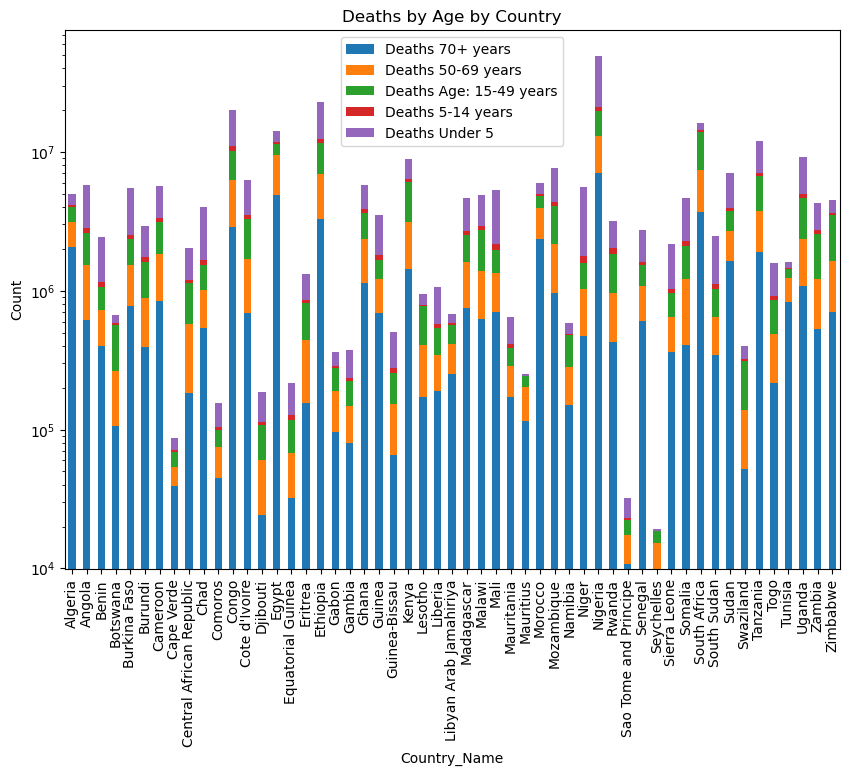

```python
afr_age_df2.plot(kind='bar', stacked=True, figsize=[10,7])
plt.title('Deaths by Age by Country')
plt.ylabel('Count')
plt.yscale('log');
```

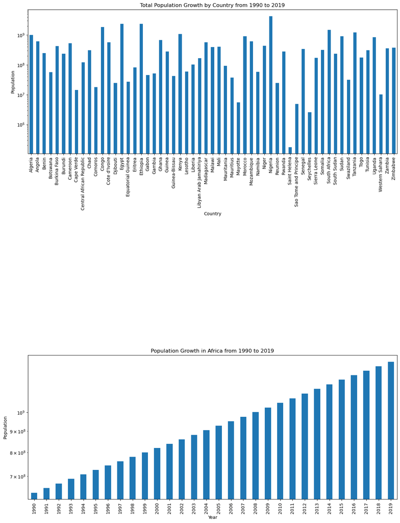

```python
plt.figure(figsize=[15,20])

plt.subplot(3,1,1)

afr_pop_df.groupby('Country_Name')['Population'].sum().plot(kind='bar')
plt.title('Total Population Growth by Country from 1990 to 2019')
plt.xlabel('Country')
plt.ylabel('Population')
plt.yscale('log')

plt.subplot(3,1,3)

afr_pop_df.groupby('Year')['Population'].sum().plot(kind='bar')
plt.title('Population Growth in Africa from 1990 to 2019')
plt.ylabel('Population')
plt.yscale('log');
```

The fisrt chart shows the total population growth by country from 1990 to 2019.

The second chart shows the population growth in Africa from 1990 to 2019.

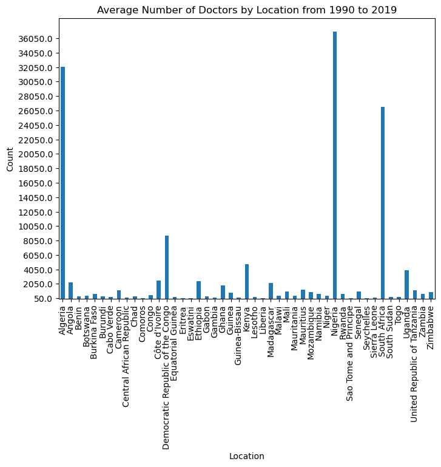

```python
#Doctors per 10,000 persons
tick=np.arange(50, mx+500, 2000)

plt.figure(figsize=[8,6])
afr_doctors.groupby('Location')['Value'].mean().plot(kind='bar')
plt.title('Average Number of Doctors by Location from 1990 to 2019')
plt.ylabel('Count')
plt.yticks(tick, tick);
```

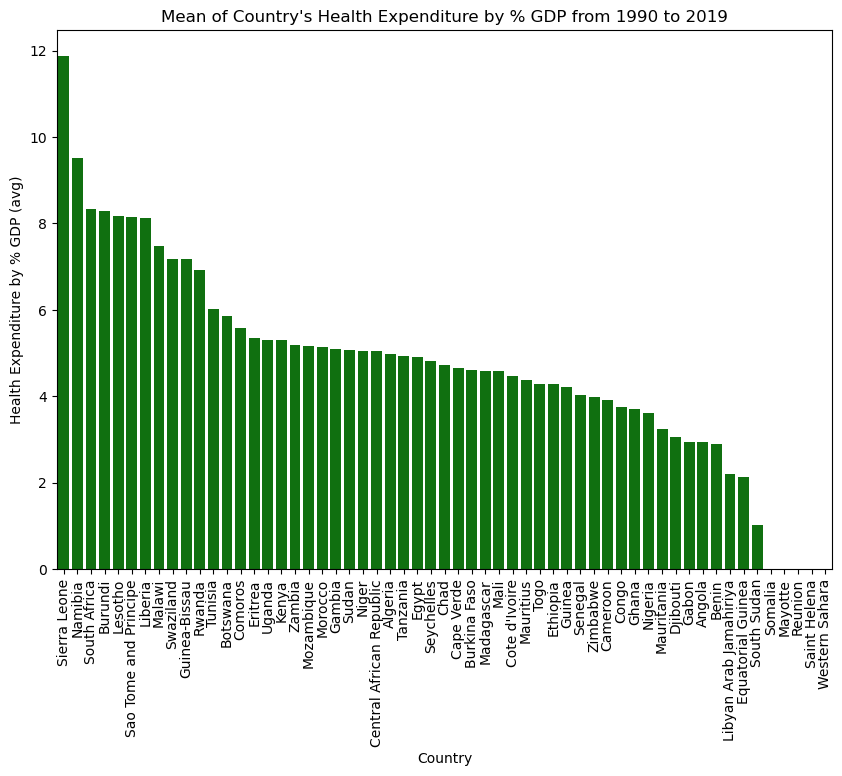

```python
ax = afr_che_df.loc[:,['Country_Name','Mean']].sort_values('Mean', ascending=False)

plt.figure(figsize=[10,7])

sb.barplot(data=ax, x='Country_Name', y='Mean', color='green')

plt.title('Mean of Country\'s Health Expenditure by % GDP from 1990 to 2019')
plt.xlabel('Country')
plt.ylabel('Health Expenditure by % GDP (avg)')
plt.xticks(rotation= 90);
```

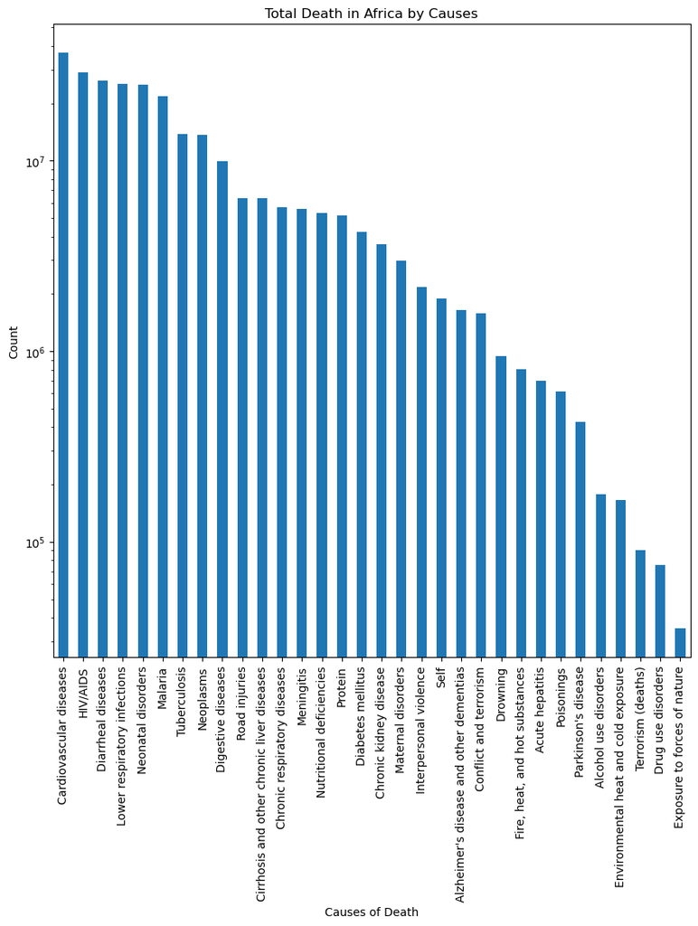

```python
plt.figure(figsize=[10,10])
ax_df.plot(kind="bar")
plt.title("Total Death in Africa by Causes")
plt.xlabel("Causes of Death")
plt.ylabel("Count")
plt.yscale('log');
```

The chart shows the prevalent causes of death in Africa. A greater population is likely to die off by cardiovascular diseases, HIV/AIDS, diarrheal diseases, etc. Fewer than 100,000 died by the forces of nature.

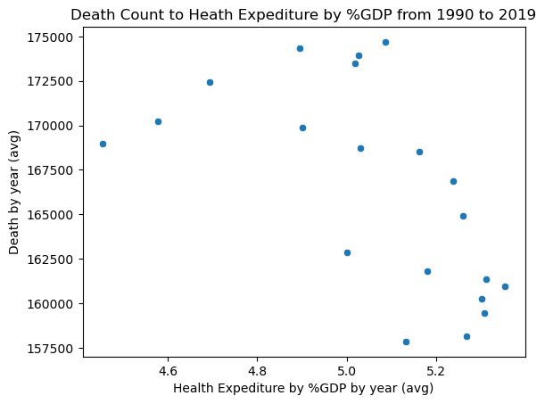

```python
sb.scatterplot(data=chdr, y='Total Death', x='Health exp by %GDP', )
plt.title('Death Count to Heath Expediture by %GDP from 1990 to 2019')
plt.ylabel('Death by year (avg)')
plt.xlabel('Health Expediture by %GDP by year (avg)');
```

## RECOMMENDATION

From the insights generated, I can recommend that:

1. Africa needs to have an efficient plan to take care of its elderly.
2. Increase spending in the health sector.
3. Employ more doctors esppecially in countries with a higher population.
4. Set up measures to tackle cardiovascular diseases, HIV/AIDS, diarrheal, etc.